# 16_rotate_2D_points

## 16_rotate_2D_points

#### Question

## Matrix of original points (preimage)

1. A list of 2D-cartesian points is stored as the preimage matrix. Each row represents one point.

   $$P = \begin{bmatrix}
   -7 & 6\\
   3 & 1\\
   -3 & -3\\
   6 & -1\\
   2 & -5\\
   -5 & 3\\
   -6 & -7\\
   3 & -3\\
   -1 & -5\\
   -1 & -2
   \end{bmatrix}$$

   Those points can be expressed in [SageMath](https://sagecell.sagemath.org/).

   ```
   P = matrix([[-7,6],[3,1],[-3,-3],[6,-1],[2,-5],[-5,3],[-6,-7],[3,-3],[-1,-5],[-1,-2]])
   ```

   If you wanted to visualize those points, you could use the [point function](https://doc.sagemath.org/html/en/reference/plotting/sage/plot/point.html).

   ```
   point(P,xmin=-10,xmax=10,ymin=-10,ymax=10,size=50,aspect_ratio=1)
   ```

## Rotation matrix

   We want to rotate the points by $\theta=3.07$ radians counterclockwise. We will do this by matrix multiplication with the 2D rotation matrix. (*We are using a right-operand rotation matrix. The standard approach is to use a left-operand rotation matrix, but I think - for complicated reasons - that we’ll be better off using right-operand transformations.*)

   $$R = \begin{bmatrix}\cos(\theta) & \sin(\theta) \\ -\sin(\theta) & \cos(\theta) \end{bmatrix}$$

## Image

   We can apply the rotation to the points by using matrix multiplication. Remember, matrix multiplication is not commutative. Let $F$ represent a matrix holding the **f**inal positions of the image (after the transformation).

   $$F = P\cdot R$$

   After you calculate $F$, you can plot the points in $F$ with the following code (in SageMath):

   ```
   point(F,xmin=-10,xmax=10,ymin=-10,ymax=10,size=50)
   ```

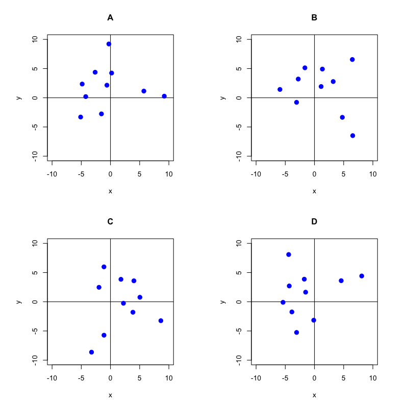

   1. A
   2. B
   3. C
   4. D

#### Question

## Matrix of original points (preimage)

2. A list of 2D-cartesian points is stored as the preimage matrix. Each row represents one point.

   $$P = \begin{bmatrix}
   1 & -4\\
   -6 & 5\\
   -4 & 0\\
   -5 & -5\\
   7 & -1\\
   -2 & -7\\
   -3 & -6\\
   3 & 5\\
   -4 & 3\\
   1 & -5\\
   0 & -6\\
   -2 & -5
   \end{bmatrix}$$

   Those points can be expressed in [SageMath](https://sagecell.sagemath.org/).

   ```
   P = matrix([[1,-4],[-6,5],[-4,0],[-5,-5],[7,-1],[-2,-7],[-3,-6],[3,5],[-4,3],[1,-5],[0,-6],[-2,-5]])
   ```

   If you wanted to visualize those points, you could use the [point function](https://doc.sagemath.org/html/en/reference/plotting/sage/plot/point.html).

   ```
   point(P,xmin=-10,xmax=10,ymin=-10,ymax=10,size=50,aspect_ratio=1)
   ```

## Rotation matrix

   We want to rotate the points by $\theta=2.51$ radians counterclockwise. We will do this by matrix multiplication with the 2D rotation matrix. (*We are using a right-operand rotation matrix. The standard approach is to use a left-operand rotation matrix, but I think - for complicated reasons - that we’ll be better off using right-operand transformations.*)

   $$R = \begin{bmatrix}\cos(\theta) & \sin(\theta) \\ -\sin(\theta) & \cos(\theta) \end{bmatrix}$$

## Image

   We can apply the rotation to the points by using matrix multiplication. Remember, matrix multiplication is not commutative. Let $F$ represent a matrix holding the **f**inal positions of the image (after the transformation).

   $$F = P\cdot R$$

   After you calculate $F$, you can plot the points in $F$ with the following code (in SageMath):

   ```
   point(F,xmin=-10,xmax=10,ymin=-10,ymax=10,size=50)
   ```

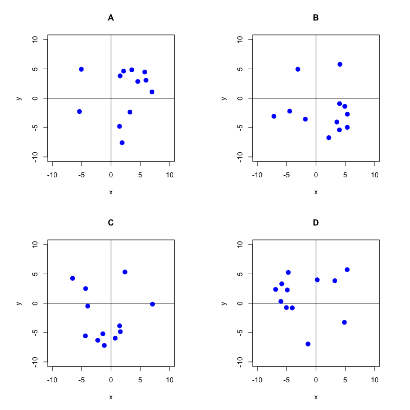

   1. A
   2. B
   3. C
   4. D

#### Question

## Matrix of original points (preimage)

3. A list of 2D-cartesian points is stored as the preimage matrix. Each row represents one point.

   $$P = \begin{bmatrix}
   7 & -1\\
   -2 & -3\\
   0 & -6\\
   -3 & 4\\
   -5 & 4\\
   -4 & -3\\
   -6 & -5\\
   3 & -7\\
   3 & -2\\
   1 & 0\\
   4 & -7\\
   7 & -6
   \end{bmatrix}$$

   Those points can be expressed in [SageMath](https://sagecell.sagemath.org/).

   ```
   P = matrix([[7,-1],[-2,-3],[0,-6],[-3,4],[-5,4],[-4,-3],[-6,-5],[3,-7],[3,-2],[1,0],[4,-7],[7,-6]])
   ```

   If you wanted to visualize those points, you could use the [point function](https://doc.sagemath.org/html/en/reference/plotting/sage/plot/point.html).

   ```
   point(P,xmin=-10,xmax=10,ymin=-10,ymax=10,size=50,aspect_ratio=1)
   ```

## Rotation matrix

   We want to rotate the points by $\theta=1.07$ radians counterclockwise. We will do this by matrix multiplication with the 2D rotation matrix. (*We are using a right-operand rotation matrix. The standard approach is to use a left-operand rotation matrix, but I think - for complicated reasons - that we’ll be better off using right-operand transformations.*)

   $$R = \begin{bmatrix}\cos(\theta) & \sin(\theta) \\ -\sin(\theta) & \cos(\theta) \end{bmatrix}$$

## Image

   We can apply the rotation to the points by using matrix multiplication. Remember, matrix multiplication is not commutative. Let $F$ represent a matrix holding the **f**inal positions of the image (after the transformation).

   $$F = P\cdot R$$

   After you calculate $F$, you can plot the points in $F$ with the following code (in SageMath):

   ```
   point(F,xmin=-10,xmax=10,ymin=-10,ymax=10,size=50)
   ```

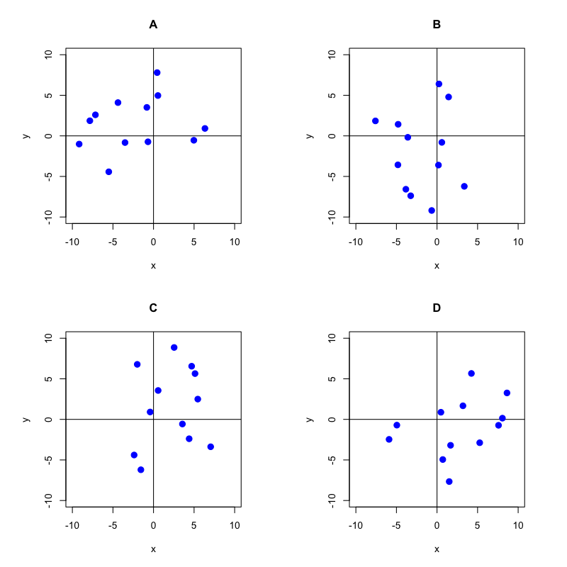

   1. A
   2. B
   3. C
   4. D

#### Question

## Matrix of original points (preimage)

4. A list of 2D-cartesian points is stored as the preimage matrix. Each row represents one point.

   $$P = \begin{bmatrix}
   4 & 4\\
   -6 & -2\\
   -2 & 5\\
   5 & 1\\
   -3 & -7\\
   -6 & 3\\
   -7 & -7\\
   -1 & -3\\
   -6 & -4\\
   -6 & 4
   \end{bmatrix}$$

   Those points can be expressed in [SageMath](https://sagecell.sagemath.org/).

   ```
   P = matrix([[4,4],[-6,-2],[-2,5],[5,1],[-3,-7],[-6,3],[-7,-7],[-1,-3],[-6,-4],[-6,4]])
   ```

   If you wanted to visualize those points, you could use the [point function](https://doc.sagemath.org/html/en/reference/plotting/sage/plot/point.html).

   ```
   point(P,xmin=-10,xmax=10,ymin=-10,ymax=10,size=50,aspect_ratio=1)
   ```

## Rotation matrix

   We want to rotate the points by $\theta=0.2$ radians counterclockwise. We will do this by matrix multiplication with the 2D rotation matrix. (*We are using a right-operand rotation matrix. The standard approach is to use a left-operand rotation matrix, but I think - for complicated reasons - that we’ll be better off using right-operand transformations.*)

   $$R = \begin{bmatrix}\cos(\theta) & \sin(\theta) \\ -\sin(\theta) & \cos(\theta) \end{bmatrix}$$

## Image

   We can apply the rotation to the points by using matrix multiplication. Remember, matrix multiplication is not commutative. Let $F$ represent a matrix holding the **f**inal positions of the image (after the transformation).

   $$F = P\cdot R$$

   After you calculate $F$, you can plot the points in $F$ with the following code (in SageMath):

   ```
   point(F,xmin=-10,xmax=10,ymin=-10,ymax=10,size=50)
   ```

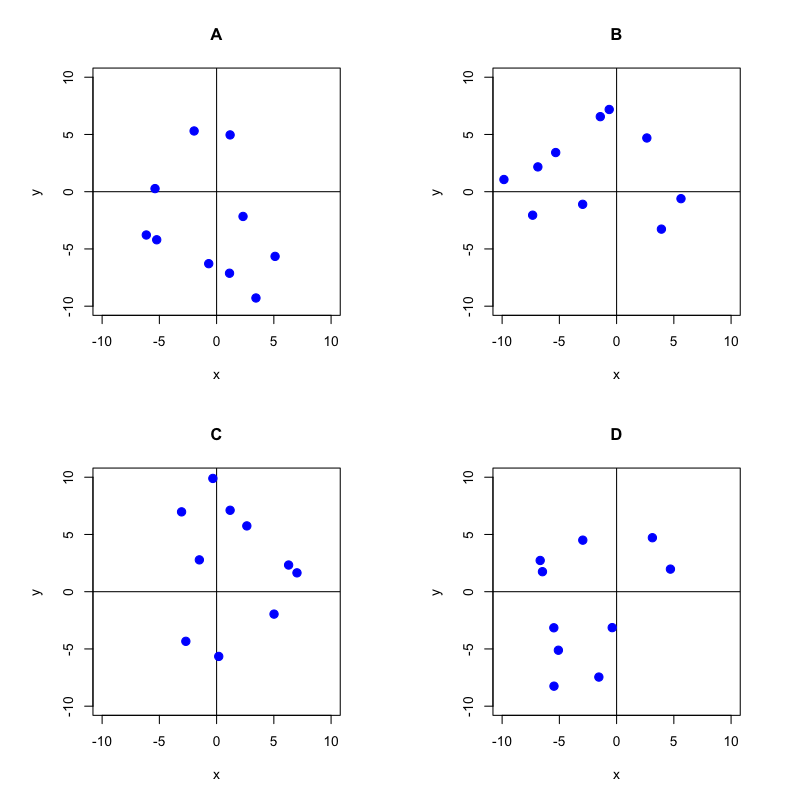

   1. A
   2. B
   3. C
   4. D

#### Question

## Matrix of original points (preimage)

5. A list of 2D-cartesian points is stored as the preimage matrix. Each row represents one point.

   $$P = \begin{bmatrix}
   -3 & 3\\
   2 & 4\\
   2 & 3\\
   -4 & 6\\
   1 & 5\\
   3 & -1\\
   2 & 7\\
   6 & 7\\
   -2 & -1\\
   -5 & -3\\
   4 & 5\\
   -2 & -2
   \end{bmatrix}$$

   Those points can be expressed in [SageMath](https://sagecell.sagemath.org/).

   ```
   P = matrix([[-3,3],[2,4],[2,3],[-4,6],[1,5],[3,-1],[2,7],[6,7],[-2,-1],[-5,-3],[4,5],[-2,-2]])
   ```

   If you wanted to visualize those points, you could use the [point function](https://doc.sagemath.org/html/en/reference/plotting/sage/plot/point.html).

   ```
   point(P,xmin=-10,xmax=10,ymin=-10,ymax=10,size=50,aspect_ratio=1)
   ```

## Rotation matrix

   We want to rotate the points by $\theta=3.31$ radians counterclockwise. We will do this by matrix multiplication with the 2D rotation matrix. (*We are using a right-operand rotation matrix. The standard approach is to use a left-operand rotation matrix, but I think - for complicated reasons - that we’ll be better off using right-operand transformations.*)

   $$R = \begin{bmatrix}\cos(\theta) & \sin(\theta) \\ -\sin(\theta) & \cos(\theta) \end{bmatrix}$$

## Image

   We can apply the rotation to the points by using matrix multiplication. Remember, matrix multiplication is not commutative. Let $F$ represent a matrix holding the **f**inal positions of the image (after the transformation).

   $$F = P\cdot R$$

   After you calculate $F$, you can plot the points in $F$ with the following code (in SageMath):

   ```
   point(F,xmin=-10,xmax=10,ymin=-10,ymax=10,size=50)
   ```

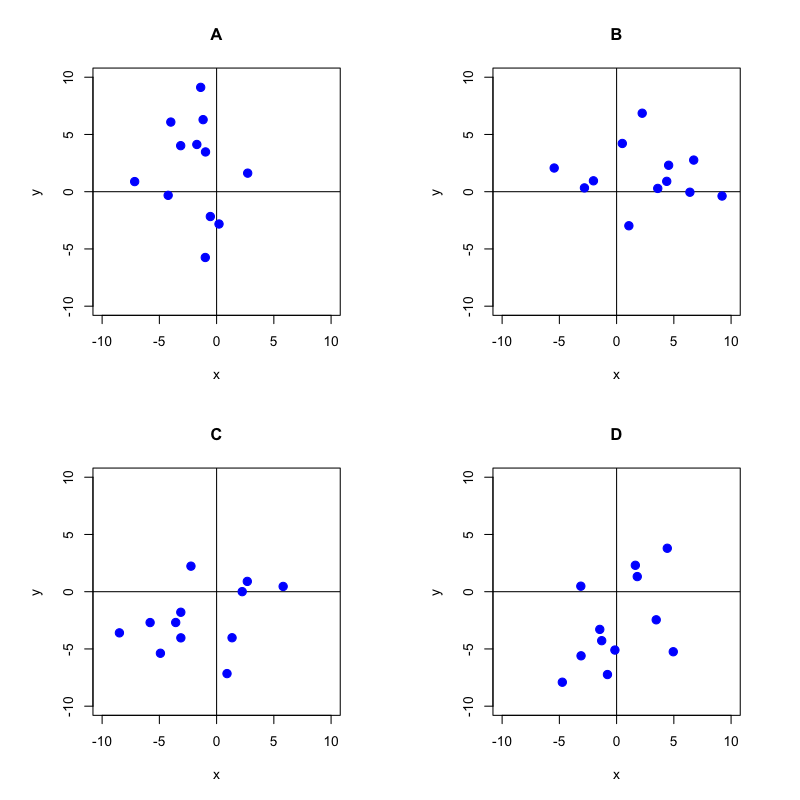

   1. A
   2. B
   3. C
   4. D

#### Question

## Matrix of original points (preimage)

6. A list of 2D-cartesian points is stored as the preimage matrix. Each row represents one point.

   $$P = \begin{bmatrix}
   -1 & -3\\
   -7 & -7\\
   -5 & 2\\
   5 & -6\\
   -1 & -4\\
   2 & 2\\
   4 & 2\\
   4 & 3\\
   -5 & 4\\
   3 & -5
   \end{bmatrix}$$

   Those points can be expressed in [SageMath](https://sagecell.sagemath.org/).

   ```
   P = matrix([[-1,-3],[-7,-7],[-5,2],[5,-6],[-1,-4],[2,2],[4,2],[4,3],[-5,4],[3,-5]])
   ```

   If you wanted to visualize those points, you could use the [point function](https://doc.sagemath.org/html/en/reference/plotting/sage/plot/point.html).

   ```
   point(P,xmin=-10,xmax=10,ymin=-10,ymax=10,size=50,aspect_ratio=1)
   ```

## Rotation matrix

   We want to rotate the points by $\theta=4.02$ radians counterclockwise. We will do this by matrix multiplication with the 2D rotation matrix. (*We are using a right-operand rotation matrix. The standard approach is to use a left-operand rotation matrix, but I think - for complicated reasons - that we’ll be better off using right-operand transformations.*)

   $$R = \begin{bmatrix}\cos(\theta) & \sin(\theta) \\ -\sin(\theta) & \cos(\theta) \end{bmatrix}$$

## Image

   We can apply the rotation to the points by using matrix multiplication. Remember, matrix multiplication is not commutative. Let $F$ represent a matrix holding the **f**inal positions of the image (after the transformation).

   $$F = P\cdot R$$

   After you calculate $F$, you can plot the points in $F$ with the following code (in SageMath):

   ```
   point(F,xmin=-10,xmax=10,ymin=-10,ymax=10,size=50)
   ```

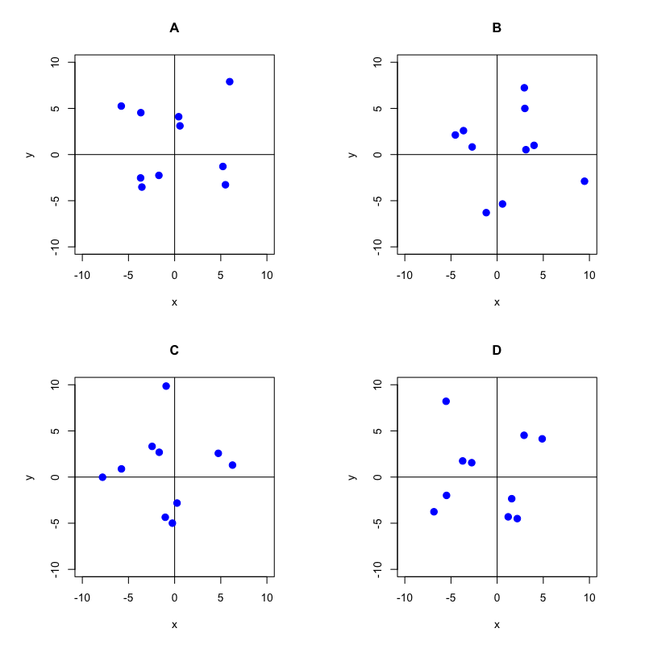

   1. A
   2. B
   3. C
   4. D

#### Question

## Matrix of original points (preimage)

7. A list of 2D-cartesian points is stored as the preimage matrix. Each row represents one point.

   $$P = \begin{bmatrix}
   -5 & -7\\
   6 & 7\\
   -6 & -5\\
   1 & 7\\
   2 & 0\\
   -6 & -4\\
   -6 & 3\\
   -1 & 6\\
   -5 & -6\\
   -2 & 6\\
   -1 & 0\\
   7 & -7
   \end{bmatrix}$$

   Those points can be expressed in [SageMath](https://sagecell.sagemath.org/).

   ```
   P = matrix([[-5,-7],[6,7],[-6,-5],[1,7],[2,0],[-6,-4],[-6,3],[-1,6],[-5,-6],[-2,6],[-1,0],[7,-7]])
   ```

   If you wanted to visualize those points, you could use the [point function](https://doc.sagemath.org/html/en/reference/plotting/sage/plot/point.html).

   ```
   point(P,xmin=-10,xmax=10,ymin=-10,ymax=10,size=50,aspect_ratio=1)
   ```

## Rotation matrix

   We want to rotate the points by $\theta=1.26$ radians counterclockwise. We will do this by matrix multiplication with the 2D rotation matrix. (*We are using a right-operand rotation matrix. The standard approach is to use a left-operand rotation matrix, but I think - for complicated reasons - that we’ll be better off using right-operand transformations.*)

   $$R = \begin{bmatrix}\cos(\theta) & \sin(\theta) \\ -\sin(\theta) & \cos(\theta) \end{bmatrix}$$

## Image

   We can apply the rotation to the points by using matrix multiplication. Remember, matrix multiplication is not commutative. Let $F$ represent a matrix holding the **f**inal positions of the image (after the transformation).

   $$F = P\cdot R$$

   After you calculate $F$, you can plot the points in $F$ with the following code (in SageMath):

   ```
   point(F,xmin=-10,xmax=10,ymin=-10,ymax=10,size=50)
   ```

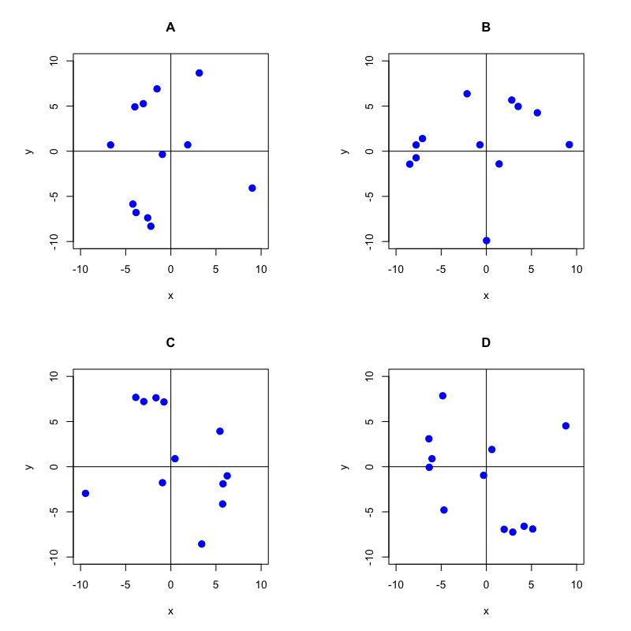

   1. A
   2. B
   3. C
   4. D

#### Question

## Matrix of original points (preimage)

8. A list of 2D-cartesian points is stored as the preimage matrix. Each row represents one point.

   $$P = \begin{bmatrix}
   -6 & 1\\
   -1 & -6\\
   -3 & 7\\
   4 & 1\\
   5 & -7\\
   6 & -1\\
   2 & -3\\
   2 & -7\\
   2 & -7\\
   2 & -3
   \end{bmatrix}$$

   Those points can be expressed in [SageMath](https://sagecell.sagemath.org/).

   ```
   P = matrix([[-6,1],[-1,-6],[-3,7],[4,1],[5,-7],[6,-1],[2,-3],[2,-7],[2,-7],[2,-3]])
   ```

   If you wanted to visualize those points, you could use the [point function](https://doc.sagemath.org/html/en/reference/plotting/sage/plot/point.html).

   ```
   point(P,xmin=-10,xmax=10,ymin=-10,ymax=10,size=50,aspect_ratio=1)
   ```

## Rotation matrix

   We want to rotate the points by $\theta=4.63$ radians counterclockwise. We will do this by matrix multiplication with the 2D rotation matrix. (*We are using a right-operand rotation matrix. The standard approach is to use a left-operand rotation matrix, but I think - for complicated reasons - that we’ll be better off using right-operand transformations.*)

   $$R = \begin{bmatrix}\cos(\theta) & \sin(\theta) \\ -\sin(\theta) & \cos(\theta) \end{bmatrix}$$

## Image

   We can apply the rotation to the points by using matrix multiplication. Remember, matrix multiplication is not commutative. Let $F$ represent a matrix holding the **f**inal positions of the image (after the transformation).

   $$F = P\cdot R$$

   After you calculate $F$, you can plot the points in $F$ with the following code (in SageMath):

   ```
   point(F,xmin=-10,xmax=10,ymin=-10,ymax=10,size=50)
   ```

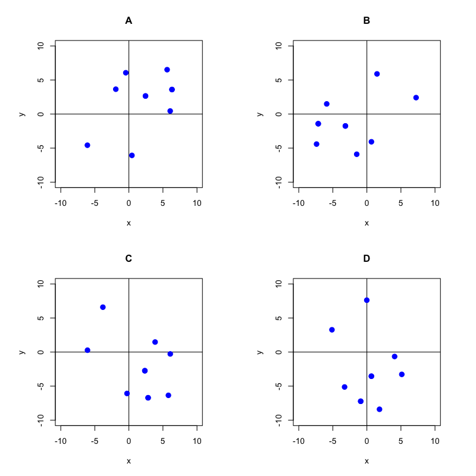

   1. A
   2. B
   3. C
   4. D